# Analyzing PML Activity Data Set

# Effect of SVM parameters

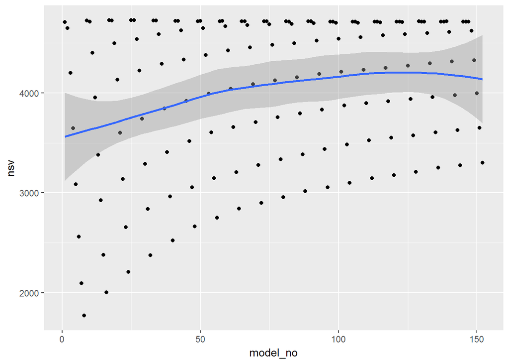

```r
qplot(x=model_no,nsv)+geom_smooth()
```

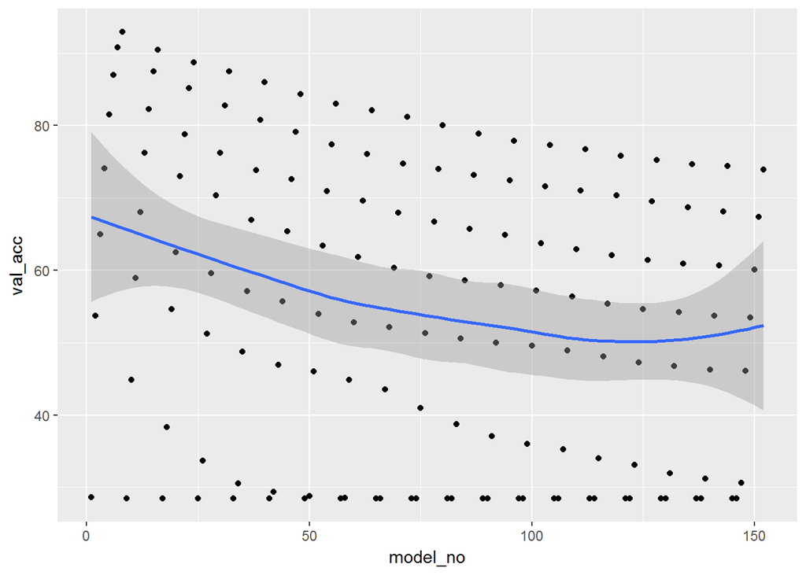

```r
qplot(x=model_no,val_acc)+geom_smooth()
```

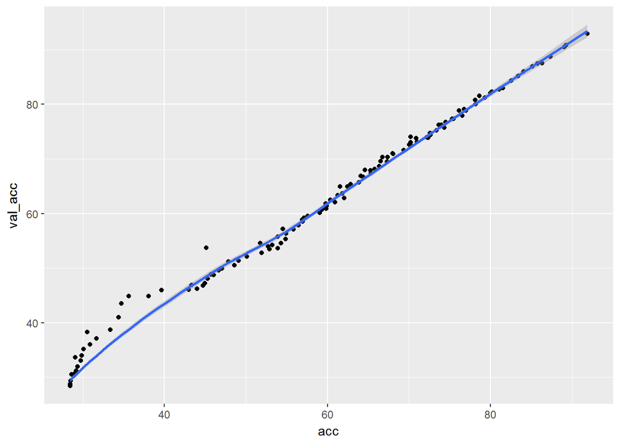

```r
qplot(x=acc,y=val_acc)+geom_smooth()
```

```r
print("Validation Accuracy of the best model:")
```

```
## [1] "Validation Accuracy of the best model:"
```

```r
print(best_val_acc)
```

```
## [1] 92.9367
```

# Final accuracy on the testing dataset

Let’s check the performance of model on the testing data that we kept aside.

```r
test_pred=predict(best_model,test_scaled[,-20])
test_acc=sum(test_pred==test_scaled$classe)*100/length(test_pred)
print("Testing Accuracy of the best model:")
```

```
## [1] "Testing Accuracy of the best model:"
```

```r
print(test_acc)
```

```
## [1] 93.83723
```

# Predictions on unseen data

Finally we provide bellow the predictions on 20 unseen observations given:

`## 1 2 3 4 5 6 7 8 9 10 11 12 13 14 15 16 17 18 19 20 ## B A C A A E D B A A B C B A E E A B B B ## Levels: A B C D E`

# Conclusions

PML dataset has many missing values.But when we analyzed it using information gain, it was found that the columns that are important do not have any missing values. We have used SVM classifier to perform classification of the dataset. We found that SVM is powerful classifier and even with 25% training data it performed pretty well. We have achieved validation accuracy above 92% and test accuracy above 93%. For the unseen test data the labels are not available. However, we have provided predictions here.